# Comparison of SAEM to multiple imputation methods on trauma data

## Miscellaneous setup

Imports

```r
## Imports
library(tidyverse)
library(verification)

# Custom imports
aux.folder = '../auxiliary/'
source(paste(aux.folder,'dataloaders.R',sep=''), chdir = T)
source(paste(aux.folder,'generate_missing.R',sep=''), chdir = T)
source(paste(aux.folder,'imputation_methods.R',sep=''), chdir = T)
source(paste(aux.folder,'prediction_methods.R',sep=''), chdir = T)
```

Parameters for this run

```r
seed = 42
dataset = 'trauma'
prop_added_missing = 0
n_imputations = 5
prediction_method = 'rf'
train_size = 0.5
max_rows = 1000
```

## Data preparation

Import and select columns

```r
# Load and format the dataset
dat = loader(dataset, max_rows, seed)
```

```
## [1] "Loading trauma data..."
## [1] "Truncating dataset (from 6269 to approximately 1000 rows)."
## [1] "Imported  14  numerical variables ( 17.5467389753104 % missing entries), and  23  categorical variables ( 24.8534074621031 % missing entries)."
## [1] "Done (1001 rows)."
```

```r
X = dat$X_numeric # For now we keep only a subset of the given data, as in Wei's work
X = X %>% dplyr::select(Age, Glasgow.moteur.initial, FC.max, Hemocue.init, Remplissage.total.cristalloides, Remplissage.total.colloides,
                        SD.min, SD.SMUR)
y=dat$y
```

Add some missing values (or not)

```r
X_miss = MCAR(X, prop_added_missing)
```

```
## [1] "Adding 0% missing observations completely at random."
## [1] "New proportion of missing data: 18.2192807192807%."
## [1] "Done."
```

## Prediction

### SAEM Prediction

```r
prediction_SAEM = saem_prediction(X_miss, y, train_size=train_size, seed=seed, printevery=50)
```

```
## [1] "Predicting response using SAEM logistic regression on 50% of the data as training set..."
## iteration = 50 beta = -2.713597 0.01433229 0.1094233 0.02710205 -0.2139772 0.0009523276 0.001574814 -0.03009163 -0.01061966
## Distance from estimator from last iter = 0.3505663
## iteration = 100 beta = -2.55658 0.01423139 0.08701616 0.02549194 -0.2066462 0.001119391 0.00157592 -0.02573278 -0.01775067
## Distance from estimator from last iter = 4.681705e-05
```

### XGBoost Prediction

```r
predictions_xgb = xgboost_prediction(X_miss, y, train_size=train_size, seed=seed, spl=prediction_SAEM$spl)
```

```
## [1] "Predicting response using XGBoost on 50% of the data as training set..."
## [1] "Existing train/test split provided. Ignoring train_size parameter."
```

### Imputed prediction

Perform multiple imputation

```r
X_imputed_mice = mice_imp(X_miss, m=n_imputations)
```

```
## [1] "Performing 5 imputations with MICE..."
## [1] "Done."
```

```r
X_imputed_amelia = amelia_imp(X_miss, m=n_imputations)
```

```
## [1] "Performing 5 imputations with Amelia..."
## -- Imputation 1 --
##
##   1  2  3  4  5  6  7  8  9 10 11 12 13
##
## -- Imputation 2 --
##
##   1  2  3  4  5  6  7  8  9 10 11 12 13 14 15 16 17 18 19 20
##  21 22 23
##
## -- Imputation 3 --
##
##   1  2  3  4  5  6  7  8  9 10 11
##
## -- Imputation 4 --
##
##   1  2  3  4  5  6  7  8  9 10 11 12 13 14
##
## -- Imputation 5 --
##
##   1  2  3  4  5  6  7  8  9 10 11 12 13 14 15
##
## [1] "Done."
```

```r
X_imputed_mi = mi_imp(X_miss, m=n_imputations)
```

```
## [1] "Performing 5 imputations with mi..."
## NOTE: In the following pairs of variables, the missingness pattern of the first is a subset of the second.
##  Please verify whether they are in fact logically distinct variables.
##      [,1]  [,2]
## [1,] "Age" "SD.SMUR"
## NOTE: In the following pairs of variables, the missingness pattern of the first is a subset of the second.
##  Please verify whether they are in fact logically distinct variables.
##      [,1]  [,2]
## [1,] "Age" "SD.SMUR"
## [1] "Done"
```

```r
#X_imputed_cat = cat_imp(X_miss, m=n_imputations)
```

Perform imputaton by the mean

```r
X_fillmean = X_miss
for(i in 1:ncol(X_fillmean)){
  c = X_fillmean[,i]
  X_fillmean[is.na(c),i] = mean(c, na.rm = T)
}
```

Fit and predict on each filled dataset using the same train/test split as with the SAEM. Here the prediction is made using any method available for caret (the choice is made at the top of the document. Here, we use a random forest estimator with no parameter tuning.)

```r
predictions_mice = multiple_prediction(X_imputed_mice, y, pred_method = prediction_method,
                                  train_size = train_size, seed=seed, spl=prediction_SAEM$spl)
```

```
## [1] "Predicting response using method rf on 50% of the data as training set..."
## [1] "Existing train/test split provided. Ignoring train_size parameter."
## [1] "Processing imputed dataset 1"
## [1] "Processing imputed dataset 2"
## [1] "Processing imputed dataset 3"
## [1] "Processing imputed dataset 4"
## [1] "Processing imputed dataset 5"
## [1] "Done."
```

```r
predictions_amelia = multiple_prediction(X_imputed_amelia, y, pred_method = prediction_method,
                                  train_size = train_size, seed=seed, spl=prediction_SAEM$spl)
```

```
## [1] "Predicting response using method rf on 50% of the data as training set..."
## [1] "Existing train/test split provided. Ignoring train_size parameter."
## [1] "Processing imputed dataset 1"
## [1] "Processing imputed dataset 2"
## [1] "Processing imputed dataset 3"
## [1] "Processing imputed dataset 4"
## [1] "Processing imputed dataset 5"
## [1] "Done."
```

```r
predictions_mi = multiple_prediction(X_imputed_mi, y, pred_method = prediction_method,
                                  train_size = train_size, seed=seed, spl=prediction_SAEM$spl)
```

```
## [1] "Predicting response using method rf on 50% of the data as training set..."
## [1] "Existing train/test split provided. Ignoring train_size parameter."
## [1] "Processing imputed dataset 1"
## [1] "Processing imputed dataset 2"
## [1] "Processing imputed dataset 3"
## [1] "Processing imputed dataset 4"
## [1] "Processing imputed dataset 5"
## [1] "Done."
```

```r
#predictions_cat = multiple_prediction(X_imputed_cat, y, pred_method = prediction_method,
#                                  train_size = train_size, seed=seed, spl=prediction_SAEM$spl)
```

Perform a single prediction on the filled dataset with the mean

```r
prediction_meanfill = multiple_prediction(list(X_fillmean), y, pred_method = prediction_method,
                                          train_size = train_size, seed=seed,spl=prediction_SAEM$spl)
```

```
## [1] "Predicting response using method rf on 50% of the data as training set..."
## [1] "Existing train/test split provided. Ignoring train_size parameter."
## [1] "Processing imputed dataset 1"
## [1] "Done."
```

Get pooled predicted values

```r
y_true = predictions_mice$y_true
y_pred_mice = pool_MI_binary(predictions_mice)
y_pred_mi = pool_MI_binary(predictions_mi)
y_pred_amelia = pool_MI_binary(predictions_amelia)
#y_pred_cat = pool_MI_binary(predictions_cat)

y_pred_SAEM = prediction_SAEM$y_pred
y_pred_xgb= predictions_xgb$y_pred
y_pred_meanfill = pool_MI_binary(prediction_meanfill)
```

## Result aggregation and comparison

Compute the average predictor for multiple imputation and regroup all the predictions in a table

```r
results = data.frame(row.names=1:length(y_true))

results$Mice = y_pred_mice
results$mi = y_pred_mi
results$amelia = y_pred_amelia

results$meanImp = y_pred_meanfill
results$SAEM = y_pred_SAEM
results$xgb = y_pred_xgb

results$Hemo.shock = as.numeric(y_true == 'X1')

print('Estimations of the probability of hemorragic shock by various methods')
```

```
## [1] "Estimations of the probability of hemorragic shock by various methods"
```

```r
head(results)
```

```
##     Mice     mi amelia meanImp       SAEM         xgb Hemo.shock
## 1 0.0136 0.1368 0.0452   0.000 0.03054688 0.002661770          0
## 2 0.0100 0.0056 0.0124   0.002 0.03353407 0.004781479          0
## 3 0.1068 0.0668 0.0792   0.118 0.01857251 0.020485990          0
## 4 0.0048 0.0156 0.0260   0.000 0.01213444 0.004250123          0
## 5 0.0020 0.0004 0.0028   0.000 0.02735372 0.001977442          0
## 6 0.1908 0.2688 0.2168   0.028 0.15295616 0.003400626          0
```

Plot the ROC curve for these estimators. The number in the legend is the AUC (are under the ROC curve) for each model.

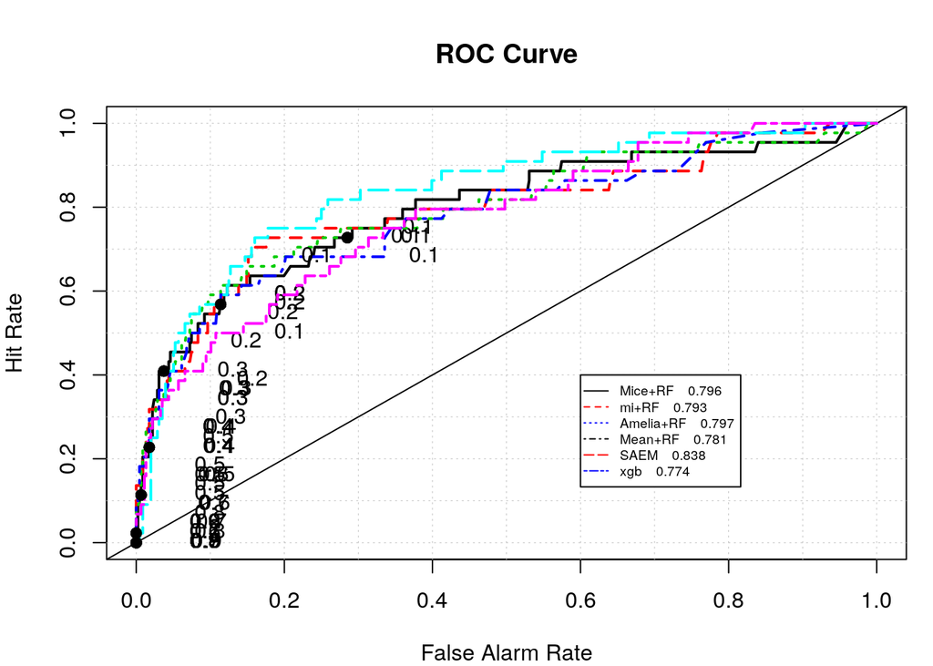

```r
roc.plot(results$Hemo.shock, results[,1:6], legend=T, leg.text=c("Mice+RF", "mi+RF", 'Amelia+RF', 'Mean+RF', 'SAEM', 'xgb'))
```